# Molecular Mechanism of Cisplatin Resistance

RNA-Seq Analysis of Human Lung Cancer Cells

Bioinformatics Analyst

2025-12-09

## 1. Executive Summary

In this project, we analyzed the transcriptomic landscape of **Cisplatin-Resistant** vs. **Sensitive** lung cancer cells (A549 cell line). The goal was to identify key molecular mechanisms driving drug resistance.

**Key Findings:** 1. **Oxidative Stress Response** is significantly upregulated in resistant cells. 2. **Metabolic Reprogramming** (Glucose transport) is activated to support cell survival. 3. **Cell Adhesion** pathways are altered, suggesting potential metastatic features.

## 2. Differential Expression Analysis

We compared gene expression profiles to identify Up-regulated (Resistance drivers) and Down-regulated genes.

### Volcano Plot Visualization

The plot below illustrates the global distribution of differentially expressed genes. Red points indicate genes with significant upregulation in resistant cells (Log2FC > 1, P-adj < 0.05).

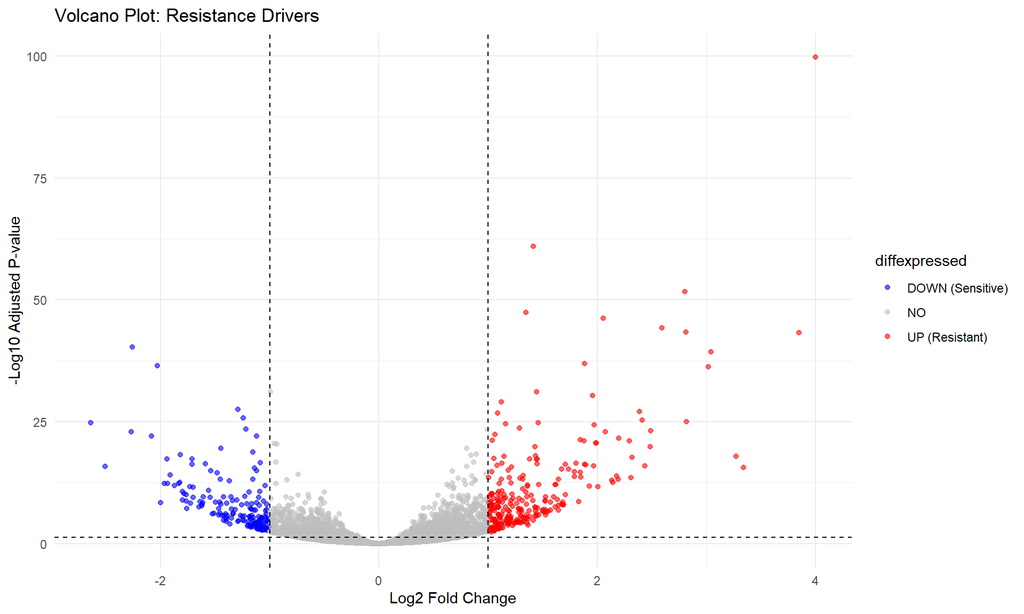

## 3. Pathway Enrichment Analysis (GSEA)

To understand the biological function of these genes, we performed Gene Set Enrichment Analysis (GSEA).

### Mechanism of Resistance

The Dotplot below reveals the top activated and suppressed biological pathways.

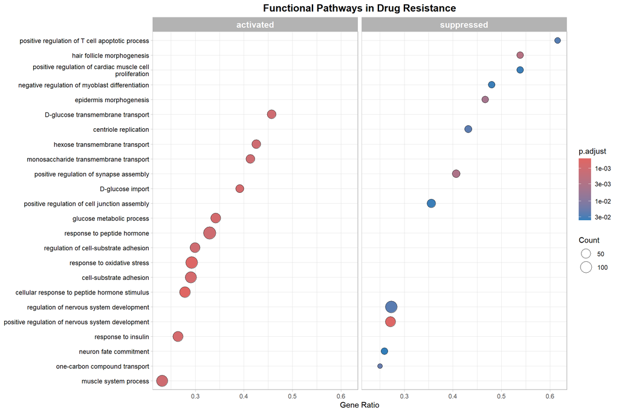

**Interpretation:** The analysis confirms that **Response to Oxidative Stress** and **Glucose Import** are the primary mechanisms utilized by cancer cells to survive Cisplatin treatment. —

## 5. Protein-Protein Interaction (PPI) Network

To identify “Hub Genes” and potential drug targets, we analyzed the protein interaction network using the **STRING database**. This analysis reveals functional clusters and master regulators of the resistance mechanism.

### Network Visualization

The graph below shows the interaction between the top 50 upregulated genes. *(Nodes with more connections are considered Hub Genes)*.

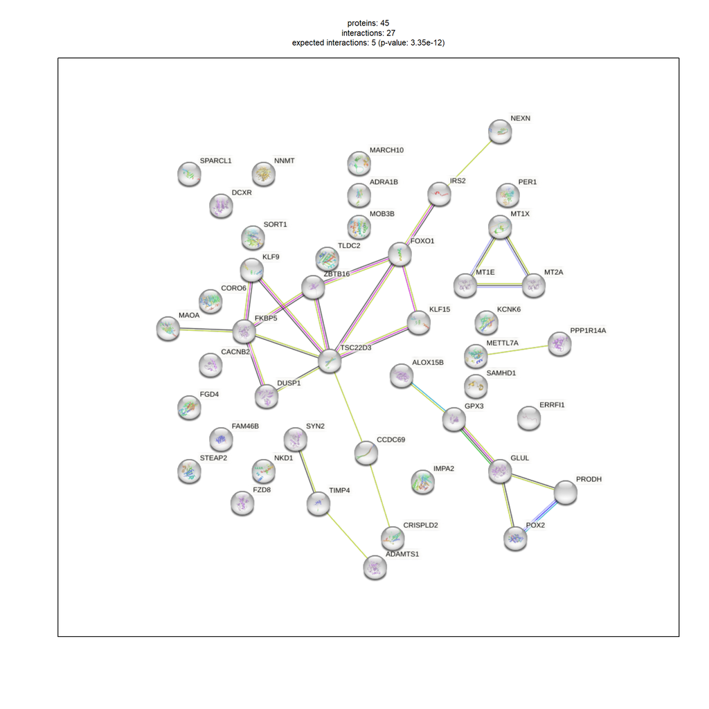

## 4. Data Availability (Interactive Table)

The table below shows the top significant genes. You can search and filter this table.

|  | log2FoldChange | pvalue | padj |
| --- | --- | --- | --- |
| ENSG00000152583 | 3.999069167885835 | 9.88999146049434e-105 | 1.838054912932873e-100 |
| ENSG00000148175 | 1.417331406132504 | 1.221958656837328e-65 | 1.135505081866087e-61 |
| ENSG00000179094 | 2.801774473258751 | 3.132380998427908e-56 | 1.940510028526089e-52 |
| ENSG00000134686 | 1.349265459513949 | 8.043913437150226e-52 | 3.737403280735924e-48 |
| ENSG00000125148 | 2.053923652833972 | 1.609198136649421e-50 | 5.981389473925896e-47 |
| ENSG00000120129 | 2.594366588995104 | 1.891922769419409e-48 | 5.860230778276617e-45 |
| ENSG00000189221 | 2.811431204851987 | 1.413006298674144e-47 | 3.751531722979852e-44 |
| ENSG00000109906 | 3.847364459886863 | 2.491904044167709e-47 | 5.78900458260711e-44 |
| ENSG00000178695 | -2.257661232360144 | 2.335644613355547e-44 | 4.823106126579205e-41 |
| ENSG00000101347 | 3.041609332186712 | 2.459788083885583e-43 | 4.571516153901356e-40 |

[output cut: 90 more lines]

*Report generated by R Markdown - Bioinformatic Portfolio*